# Exploratory Data Analysis of the JFK Airport Data Set

```r
library(readr)
library(dplyr)       # For data manipulation
```

```r
library(ggplot2)     # For data visualization
library(summarytools) # For summary statistics
library(tidyr)
library(knitr)
library(corrplot)
library(factoextra)
library(RColorBrewer)
```

## JFK International Airport Flight Delay Data Set

This data set concerns flight delays for domestic flights departing JFK International Airport. It provides detailed information about airline, weather, airport and employment conditions. The aim of exploring this data set is to study the correlation between features and flight delays with the goal of performing a binary classification on this data set.

This data set has been created from a larger open data set available at this address: Data set available at “https://www.kaggle.com/datasets/threnjen/2019-airline-delays-and-cancellations”.

```r
flightData <- read_csv("C:/Users/USER/OneDrive/Bristol Year 4/Data Science Toolbox/Group Assessments/Assessment 1/jfk_flight_data.csv")
```

We present the features of the data set.

```r
library(dplyr)
library(knitr)
library(kableExtra)
column_descriptions <- data.frame(
  Feature = c(
    "MONTH", "DAY_OF_WEEK", "DEP_DEL15", "DEP_TIME_BLK", "DISTANCE_GROUP",
    "SEGMENT_NUMBER", "CONCURRENT_FLIGHTS", "NUMBER_OF_SEATS", "CARRIER_NAME",
    "AIRLINE_FLIGHTS_MONTH", "AIRLINE_AIRPORT_FLIGHTS_MONTH",
    "AVG_MONTHLY_PASS_AIRLINE", "FLT_ATTENDANTS_PER_PASS",
    "GROUND_SERV_PER_PASS", "PLANE_AGE", "PREVIOUS_AIRPORT", "PRCP", "SNOW", "SNWD", "TMAX", "AWND"
  ),
  Description = c(
    "Month", "Day of Week", "(TARGET) Departure Delay Indicator, 15 Minutes or More (1=Yes)",
    "CRS Departure Time Block, Hourly Intervals", "Distance group to be flown by departing aircraft",
    "The segment that this tail number is on for the day", "Concurrent flights leaving from the airport in the same departure block",
    "Number of seats on the aircraft", "Carrier",
    "Avg Airline Flights per Month", "Avg Flights per month for Airline AND Airport", "Avg Passengers for airline for month",
    "Flight attendants per passenger for airline", "Ground service employees (service desk) per passenger for airline",
    "Age of departing aircraft", "Previous airport that aircraft departed from",
    "Inches of precipitation for day", "Inches of snowfall for day",
    "Inches of snow on ground for day", "Max temperature for day", "Max wind speed for day"
  )
)

kable(column_descriptions, format = "html") %>%
  kable_styling(full_width = FALSE) %>%
  row_spec(0, bold = TRUE) %>%
  column_spec(1, width = "20%") %>%
  column_spec(2, width = "80%")
```

| Feature | Description |
| --- | --- |
| MONTH | Month |
| DAY_OF_WEEK | Day of Week |
| DEP_DEL15 | (TARGET) Departure Delay Indicator, 15 Minutes or More (1=Yes) |
| DEP_TIME_BLK | CRS Departure Time Block, Hourly Intervals |
| DISTANCE_GROUP | Distance group to be flown by departing aircraft |
| SEGMENT_NUMBER | The segment that this tail number is on for the day |
| CONCURRENT_FLIGHTS | Concurrent flights leaving from the airport in the same departure block |
| NUMBER_OF_SEATS | Number of seats on the aircraft |
| CARRIER_NAME | Carrier |
| AIRLINE_FLIGHTS_MONTH | Avg Airline Flights per Month |
| AIRLINE_AIRPORT_FLIGHTS_MONTH | Avg Flights per month for Airline AND Airport |
| AVG_MONTHLY_PASS_AIRLINE | Avg Passengers for airline for month |
| FLT_ATTENDANTS_PER_PASS | Flight attendants per passenger for airline |
| GROUND_SERV_PER_PASS | Ground service employees (service desk) per passenger for airline |
| PLANE_AGE | Age of departing aircraft |
| PREVIOUS_AIRPORT | Previous airport that aircraft departed from |
| PRCP | Inches of precipitation for day |
| SNOW | Inches of snowfall for day |
| SNWD | Inches of snow on ground for day |
| TMAX | Max temperature for day |
| AWND | Max wind speed for day |

```r
glimpse(flightData)
```

```
## Rows: 125,109
## Columns: 21
## $ MONTH                         <dbl> 1, 1, 1, 1, 1, 1, 1, 1, 1, 1, 1, 1, 1, 1…
## $ DAY_OF_WEEK                   <dbl> 5, 5, 5, 5, 5, 5, 5, 5, 5, 5, 5, 5, 5, 5…
## $ DEP_DEL15                     <dbl> 0, 0, 0, 0, 0, 0, 0, 0, 0, 0, 0, 0, 0, 0…
## $ DEP_TIME_BLK                  <chr> "2000-2059", "0800-0859", "0600-0659", "…
## $ DISTANCE_GROUP                <dbl> 8, 11, 8, 11, 5, 7, 5, 7, 10, 10, 10, 10…
## $ SEGMENT_NUMBER                <dbl> 1, 1, 1, 1, 1, 1, 1, 1, 1, 1, 1, 1, 1, 1…
## $ CONCURRENT_FLIGHTS            <dbl> 16, 36, 12, 19, 33, 23, 36, 21, 33, 21, …
## $ NUMBER_OF_SEATS               <dbl> 180, 160, 168, 168, 157, 157, 191, 157, …
## $ CARRIER_NAME                  <chr> "Delta Air Lines Inc.", "Delta Air Lines…
## $ AIRLINE_FLIGHTS_MONTH         <dbl> 73508, 73508, 73508, 73508, 73508, 73508…
## $ AIRLINE_AIRPORT_FLIGHTS_MONTH <dbl> 2527, 2527, 2527, 2527, 2527, 2527, 2527…
## $ AVG_MONTHLY_PASS_AIRLINE      <dbl> 12460183, 12460183, 12460183, 12460183, …
## $ FLT_ATTENDANTS_PER_PASS       <dbl> 1.441659e-04, 1.441659e-04, 1.441659e-04…
## $ GROUND_SERV_PER_PASS          <dbl> 0.0001486602, 0.0001486602, 0.0001486602…
## $ PLANE_AGE                     <dbl> 1, 18, 19, 22, 28, 28, 1, 28, 27, 15, 17…
## $ PREVIOUS_AIRPORT              <chr> "NONE", "NONE", "NONE", "NONE", "NONE", …
## $ PRCP                          <dbl> 0, 0, 0, 0, 0, 0, 0, 0, 0, 0, 0, 0, 0, 0…
## $ SNOW                          <dbl> 0, 0, 0, 0, 0, 0, 0, 0, 0, 0, 0, 0, 0, 0…
## $ SNWD                          <dbl> 0, 0, 0, 0, 0, 0, 0, 0, 0, 0, 0, 0, 0, 0…
## $ TMAX                          <dbl> 32, 32, 32, 32, 32, 32, 32, 32, 32, 32, …
## $ AWND                          <dbl> 19.01, 19.01, 19.01, 19.01, 19.01, 19.01…
```

```r
head(flightData)
```

| MONTH | DAY_OF_WEEK | DEP_DEL15 | DEP_TIME_BLK | DISTANCE_GROUP | SEGMENT_NUMBER | CONCURRENT_FLIGHTS | NUMBER_OF_SEATS | CARRIER_NAME | AIRLINE_FLIGHTS_MONTH | AIRLINE_AIRPORT_FLIGHTS_MONTH | AVG_MONTHLY_PASS_AIRLINE | FLT_ATTENDANTS_PER_PASS | GROUND_SERV_PER_PASS | PLANE_AGE | PREVIOUS_AIRPORT | PRCP | SNOW | SNWD | TMAX | AWND |
| --- | --- | --- | --- | --- | --- | --- | --- | --- | --- | --- | --- | --- | --- | --- | --- | --- | --- | --- | --- | --- |
| 1 | 5 | 0 | 2000-2059 | 8 | 1 | 16 | 180 | Delta Air Lines Inc. | 73508 | 2527 | 12460183 | 0.0001441659 | 0.0001486602 | 1 | NONE | 0 | 0 | 0 | 32 | 19.01 |
| 1 | 5 | 0 | 0800-0859 | 11 | 1 | 36 | 160 | Delta Air Lines Inc. | 73508 | 2527 | 12460183 | 0.0001441659 | 0.0001486602 | 18 | NONE | 0 | 0 | 0 | 32 | 19.01 |
| 1 | 5 | 0 | 0600-0659 | 8 | 1 | 12 | 168 | Delta Air Lines Inc. | 73508 | 2527 | 12460183 | 0.0001441659 | 0.0001486602 | 19 | NONE | 0 | 0 | 0 | 32 | 19.01 |
| 1 | 5 | 0 | 1700-1759 | 11 | 1 | 19 | 168 | Delta Air Lines Inc. | 73508 | 2527 | 12460183 | 0.0001441659 | 0.0001486602 | 22 | NONE | 0 | 0 | 0 | 32 | 19.01 |
| 1 | 5 | 0 | 1900-1959 | 5 | 1 | 33 | 157 | Delta Air Lines Inc. | 73508 | 2527 | 12460183 | 0.0001441659 | 0.0001486602 | 28 | NONE | 0 | 0 | 0 | 32 | 19.01 |
| 1 | 5 | 0 | 0900-0959 | 7 | 1 | 23 | 157 | Delta Air Lines Inc. | 73508 | 2527 | 12460183 | 0.0001441659 | 0.0001486602 | 28 | NONE | 0 | 0 | 0 | 32 | 19.01 |

```r
summary(flightData)
```

```
##      MONTH         DAY_OF_WEEK      DEP_DEL15      DEP_TIME_BLK
##  Min.   : 1.000   Min.   :1.000   Min.   :0.0000   Length:125109
##  1st Qu.: 4.000   1st Qu.:2.000   1st Qu.:0.0000   Class :character
##  Median : 6.000   Median :4.000   Median :0.0000   Mode  :character
##  Mean   : 6.503   Mean   :3.965   Mean   :0.1891
##  3rd Qu.: 9.000   3rd Qu.:6.000   3rd Qu.:0.0000
##  Max.   :12.000   Max.   :7.000   Max.   :1.0000
##  DISTANCE_GROUP   SEGMENT_NUMBER   CONCURRENT_FLIGHTS NUMBER_OF_SEATS
##  Min.   : 1.000   Min.   : 1.000   Min.   : 1.00      Min.   : 44.0
##  1st Qu.: 2.000   1st Qu.: 1.000   1st Qu.:17.00      1st Qu.:100.0
##  Median : 5.000   Median : 2.000   Median :22.00      Median :150.0
##  Mean   : 5.528   Mean   : 2.471   Mean   :21.76      Mean   :134.1
##  3rd Qu.: 9.000   3rd Qu.: 3.000   3rd Qu.:26.00      3rd Qu.:168.0
##  Max.   :11.000   Max.   :10.000   Max.   :40.00      Max.   :304.0
##  CARRIER_NAME       AIRLINE_FLIGHTS_MONTH AIRLINE_AIRPORT_FLIGHTS_MONTH
##  Length:125109      Min.   : 6020         Min.   :   4
##  Class :character   1st Qu.:23463         1st Qu.:1478
##  Mode  :character   Median :25270         Median :2719
##                     Mean   :46444         Mean   :2317
##                     3rd Qu.:79228         3rd Qu.:3317
##                     Max.   :91062         Max.   :3668
##  AVG_MONTHLY_PASS_AIRLINE FLT_ATTENDANTS_PER_PASS GROUND_SERV_PER_PASS
##  Min.   :  905990         Min.   :0.000e+00       Min.   :0.0000900
##  1st Qu.: 2884187         1st Qu.:3.419e-05       1st Qu.:0.0001269
##  Median : 3190369         Median :1.442e-04       Median :0.0001269
##  Mean   : 6190425         Mean   :1.171e-04       Mean   :0.0001338
##  3rd Qu.:12460183         3rd Qu.:1.600e-04       3rd Qu.:0.0001487
##  Max.   :12460183         Max.   :3.484e-04       Max.   :0.0001978
##    PLANE_AGE     PREVIOUS_AIRPORT        PRCP             SNOW
##  Min.   : 0.00   Length:125109      Min.   :0.0000   Min.   :0.00000
##  1st Qu.: 5.00   Class :character   1st Qu.:0.0000   1st Qu.:0.00000
##  Median :11.00   Mode  :character   Median :0.0000   Median :0.00000
##  Mean   :10.63                      Mean   :0.1353   Mean   :0.03981
##  3rd Qu.:16.00                      3rd Qu.:0.0700   3rd Qu.:0.00000
##  Max.   :29.00                      Max.   :2.6700   Max.   :3.80000
##       SNWD              TMAX             AWND
##  Min.   :0.00000   Min.   : 16.00   Min.   : 4.03
##  1st Qu.:0.00000   1st Qu.: 47.00   1st Qu.: 8.05
##  Median :0.00000   Median : 64.00   Median : 9.62
##  Mean   :0.03415   Mean   : 63.36   Mean   :10.74
##  3rd Qu.:0.00000   3rd Qu.: 79.00   3rd Qu.:12.30
##  Max.   :3.90000   Max.   :100.00   Max.   :27.07
```

```r
missing_values <- flightData %>%
  summarise_all(~ sum(is.na(.)))

missing_values
```

| MONTH | DAY_OF_WEEK | DEP_DEL15 | DEP_TIME_BLK | DISTANCE_GROUP | SEGMENT_NUMBER | CONCURRENT_FLIGHTS | NUMBER_OF_SEATS | CARRIER_NAME | AIRLINE_FLIGHTS_MONTH | AIRLINE_AIRPORT_FLIGHTS_MONTH | AVG_MONTHLY_PASS_AIRLINE | FLT_ATTENDANTS_PER_PASS | GROUND_SERV_PER_PASS | PLANE_AGE | PREVIOUS_AIRPORT | PRCP | SNOW | SNWD | TMAX | AWND |
| --- | --- | --- | --- | --- | --- | --- | --- | --- | --- | --- | --- | --- | --- | --- | --- | --- | --- | --- | --- | --- |
| 0 | 0 | 0 | 0 | 0 | 0 | 0 | 0 | 0 | 0 | 0 | 0 | 0 | 0 | 0 | 0 | 0 | 0 | 0 | 0 | 0 |

### Examining the proportion of delays by carrier.

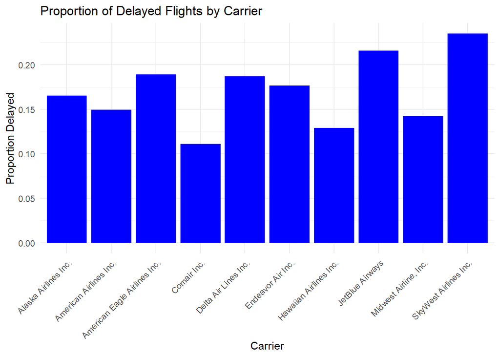

```r
# Bar chart of carrier vs proportion of delays
delayed_proportions <- flightData %>%
  group_by(CARRIER_NAME) %>%
  summarize(proportion_delayed = mean(DEP_DEL15 == 1))

ggplot(delayed_proportions, aes(x = CARRIER_NAME, y = proportion_delayed)) +
  geom_bar(stat = "identity", fill = "blue") +
  labs(
    title = "Proportion of Delayed Flights by Carrier",
    x = "Carrier",
    y = "Proportion Delayed"
  ) +
  theme_minimal() +
  theme(axis.text.x = element_text(angle = 45, hjust = 1))
```

We see that “SkyWest Airlines Inc.” and “JetBlue Airways” have the highest proportions of delayed flights, while “Comair Inc,” has the lowest.

### Examining the proportion of delays by month of the year.

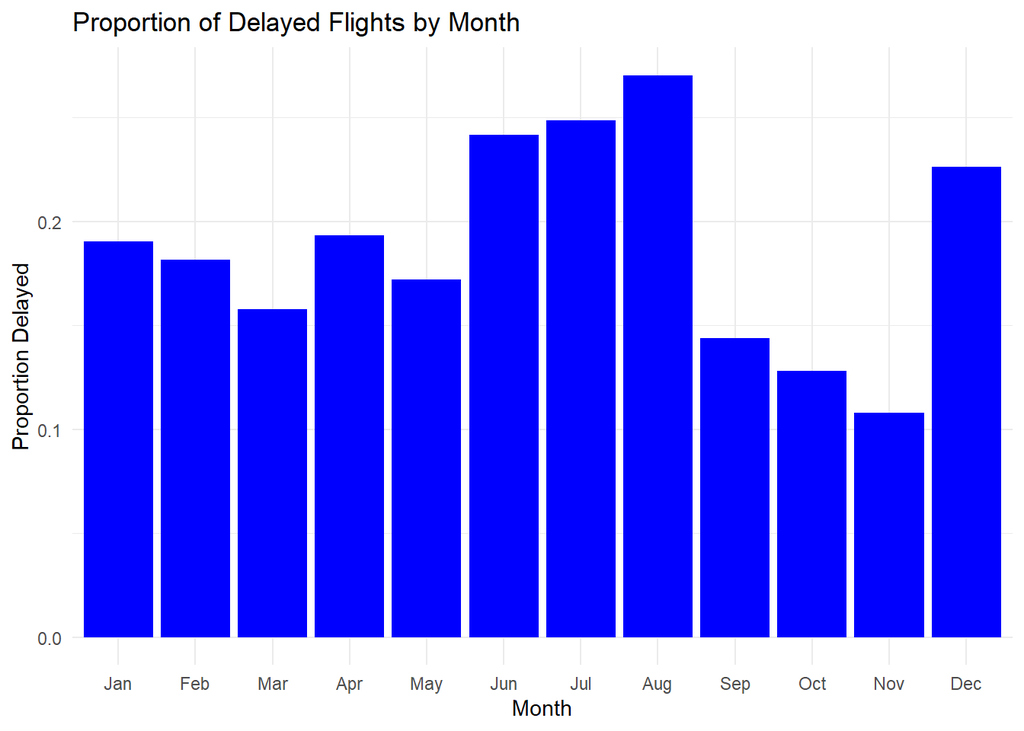

```r
delayed_proportions <- flightData %>%
  group_by(MONTH) %>%
  summarize(proportion_delayed = mean(DEP_DEL15 == 1))

#flightData$MONTH <- factor(flightData$MONTH, levels = month.abb)

ggplot(delayed_proportions, aes(x = MONTH, y = proportion_delayed)) +
  geom_bar(stat = "identity", fill = "blue") +
  labs(
    title = "Proportion of Delayed Flights by Month",
    x = "Month",
    y = "Proportion Delayed"
  ) +
  theme_minimal() +
 scale_x_discrete(limits = month.abb)
```

### Examining the proportion of delays by day of the week.

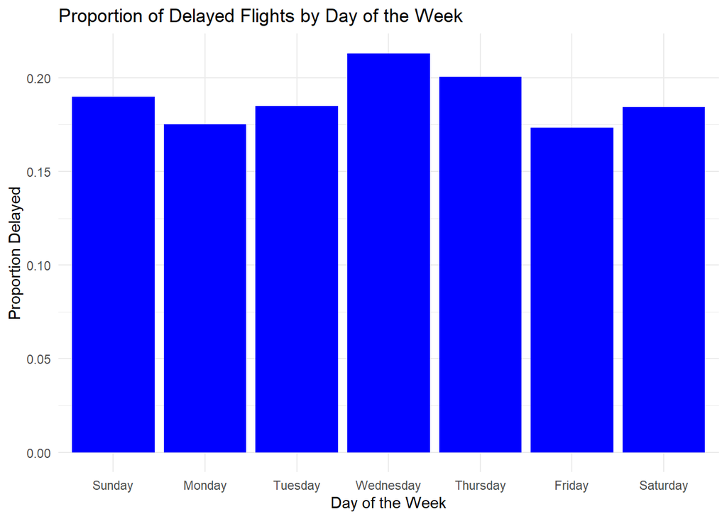

```r
delayed_proportions <- flightData %>%
  group_by(DAY_OF_WEEK) %>%
  summarize(proportion_delayed = mean(DEP_DEL15 == 1))

day_order <- c("Sunday", "Monday", "Tuesday", "Wednesday", "Thursday", "Friday", "Saturday")

#flightData$DAY_OF_WEEK <- factor(flightData$DAY_OF_WEEK, levels = day_order)

ggplot(delayed_proportions, aes(x = DAY_OF_WEEK, y = proportion_delayed)) +
  geom_bar(stat = "identity", fill = "blue") +
  labs(
    title = "Proportion of Delayed Flights by Day of the Week",
    x = "Day of the Week",
    y = "Proportion Delayed"
  ) +
  theme_minimal() +
  scale_x_discrete(limits = day_order)
```

The appears to only be slight variation between days of the week.

### Examining the proportion of delays by departure block.

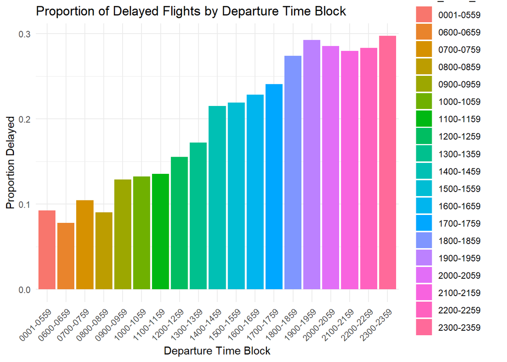

```r
delayed_proportions <- flightData %>%
  group_by(DEP_TIME_BLK) %>%
  summarize(proportion_delayed = mean(DEP_DEL15 == 1))


ggplot(delayed_proportions, aes(x = DEP_TIME_BLK, y = proportion_delayed, fill = DEP_TIME_BLK)) +
  geom_bar(stat = "identity") +
  labs(
    title = "Proportion of Delayed Flights by Departure Time Block",
    x = "Departure Time Block",
    y = "Proportion Delayed"
  ) +
  theme_minimal() +
  theme(axis.text.x = element_text(angle = 45, hjust = 1))
```

We see that there is a rise in the proportion of flight delays up to 12am where it drops back down. The highest proportions of flight delays are in the evening at departure blocks between 6pm - 12am.

### Examining the proportion of delays by Previous Airport.

```r
delayed_proportions_airport <- flightData %>%
  group_by(PREVIOUS_AIRPORT) %>%
  summarize(proportion_delayed = mean(DEP_DEL15 == 1)) %>%
  arrange(desc(proportion_delayed))

# Select top N airports and group the rest as 'Others'
top_airports <- delayed_proportions_airport %>% top_n(30)  # Selecting top 30 airports
```

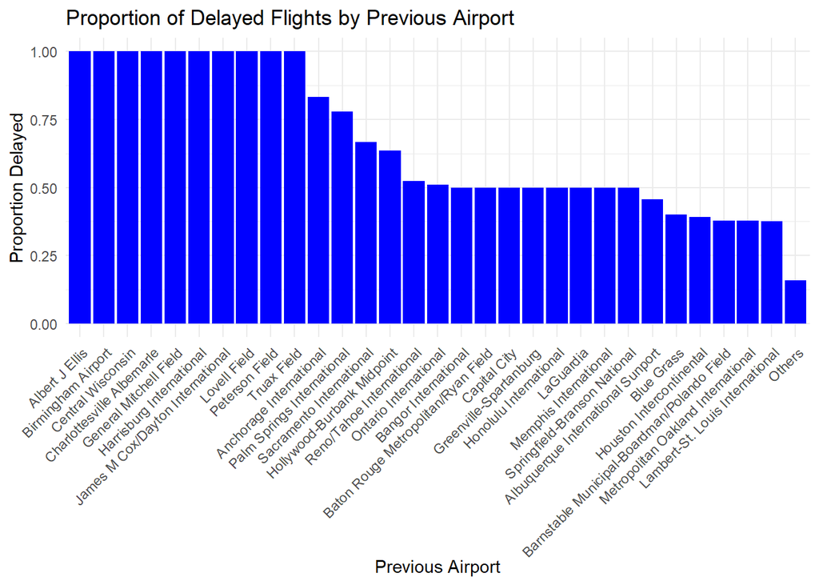

```r
other_airports <- delayed_proportions_airport %>% anti_join(top_airports, by = "PREVIOUS_AIRPORT") %>%
  summarize(PREVIOUS_AIRPORT = "Others", proportion_delayed = mean(proportion_delayed))

plot_data <- bind_rows(top_airports, other_airports)


ggplot(plot_data, aes(x = factor(PREVIOUS_AIRPORT, levels = c(as.character(top_airports$PREVIOUS_AIRPORT), "Others")), y = proportion_delayed)) +
  geom_col(fill = "blue") +
  labs(
    title = "Proportion of Delayed Flights by Previous Airport",
    x = "Previous Airport",
    y = "Proportion Delayed"
  ) +
  theme_minimal() +
  theme(axis.text.x = element_text(angle = 45, hjust = 1))
```

### Correlation plot of all numerical variables

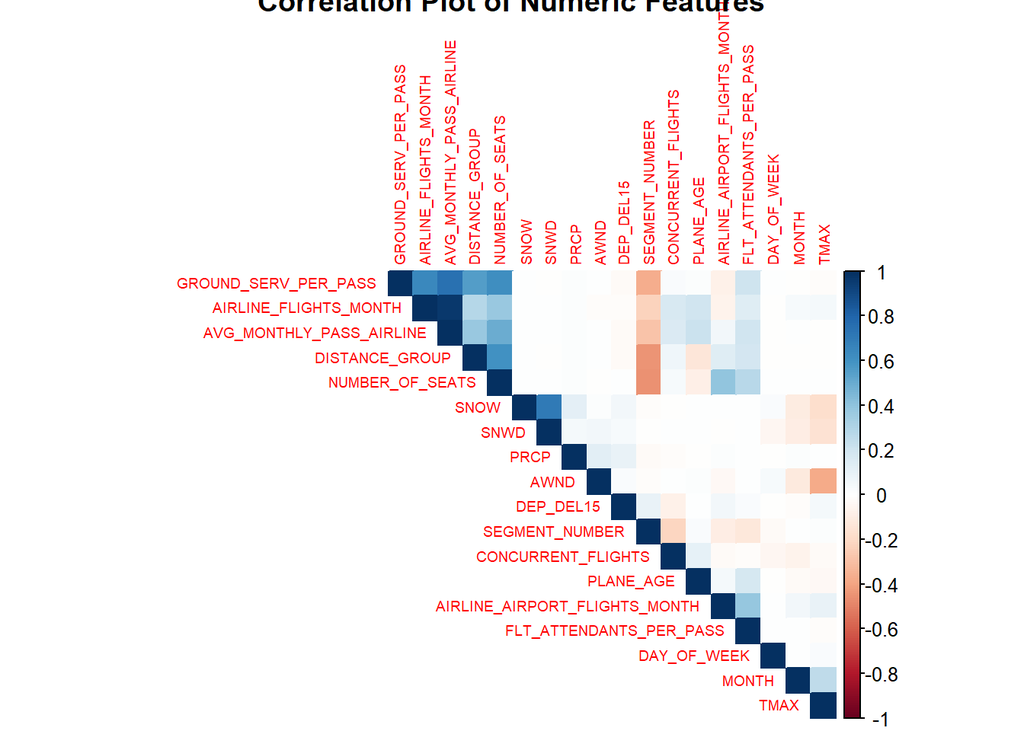

```r
filtered_data <- flightData %>%
  select_if(is.numeric)

corr <- cor(filtered_data)

corrplot(corr, method = "color", type = "upper", order = "hclust", tl.cex = 0.6, title = "Correlation Plot of Numeric Features")
```

### Examining the correlation between airport information + flight delays

We look at only numeric features that concern the departing airport and airline and the flight departures, and perform correlation analysis and PCA.

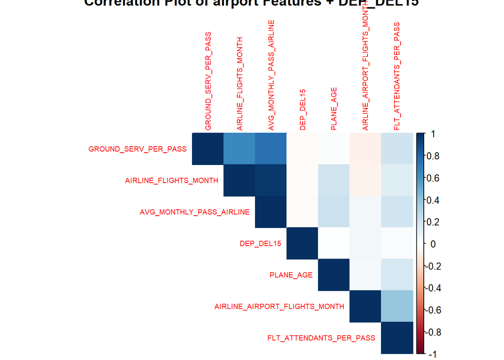

```r
airport_vars <- c(
  "AIRLINE_FLIGHTS_MONTH", "AIRLINE_AIRPORT_FLIGHTS_MONTH",
  "AVG_MONTHLY_PASS_AIRLINE",
  "FLT_ATTENDANTS_PER_PASS", "GROUND_SERV_PER_PASS", "PLANE_AGE",
  "DEP_DEL15"
)

filtered_data <- flightData %>%
  select(all_of(airport_vars))

corr <- cor(filtered_data)

corrplot(corr, method = "color", type = "upper", order = "hclust", tl.cex = 0.6, title = "Correlation Plot of airport Features + DEP_DEL15")
```

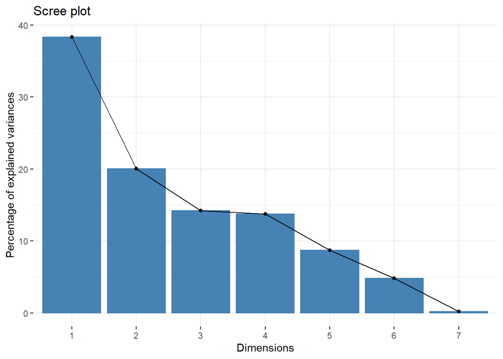

```r
outpca <- prcomp(filtered_data, center = TRUE, scale. = TRUE)

p1 <- fviz_eig(outpca)
p1
```

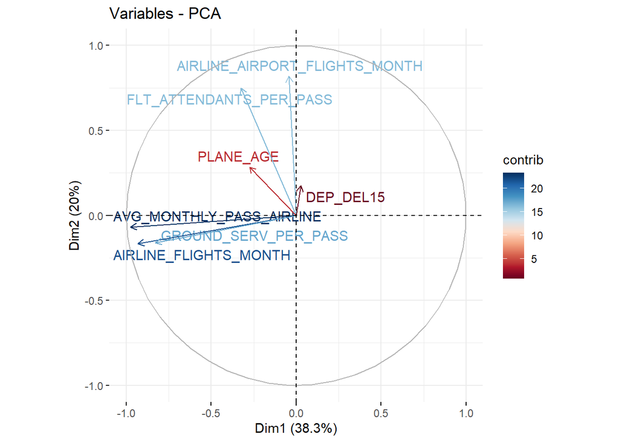

```r
p2 <- fviz_pca_var(outpca,
                   axes = c(1, 2),
                   col.var = "contrib",
                   gradient.cols = brewer.pal(n = 10, name = "RdBu"),
                   repel = TRUE
)
p2
```

Based on the correlation plot and the pca feature plot, We observe a positive correlation between the flight delays variable - “DEP_DEL15” and the variables, “AIRLINE_AIRPORT_FLIGHTS_MONTH”, with which it has the largest correlation as well as with “FLT_ATTENDANTS_PER_PASS” and “PLANE_AGE”.

### Examining the correlation between weather information + flight delays

We look at only numeric features that concern the weather and the flight departures, and perform correlation analysis and PCA.

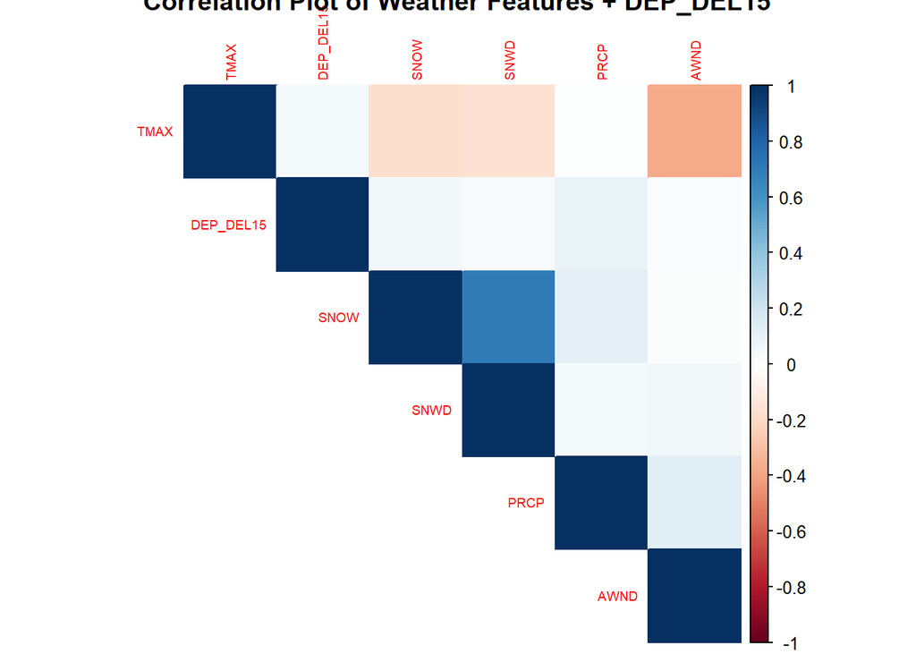

```r
weather_vars <- c("PRCP",   "SNOW", "SNWD", "TMAX", "AWND", "DEP_DEL15")

filtered_data <- flightData %>%
  select(all_of(weather_vars))

corr <- cor(filtered_data)

corrplot(corr, method = "color", type = "upper", order = "hclust", tl.cex = 0.6, title = "Correlation Plot of Weather Features + DEP_DEL15")
```

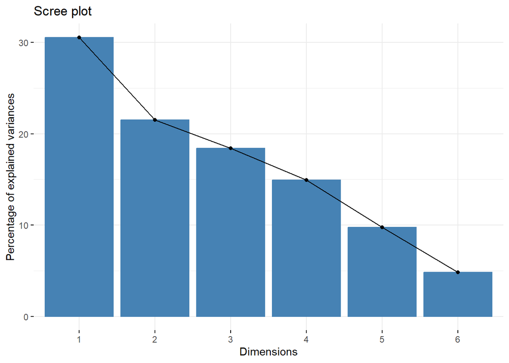

```r
outpca <- prcomp(filtered_data, center = TRUE, scale. = TRUE)

p1 <- fviz_eig(outpca)
p1
```

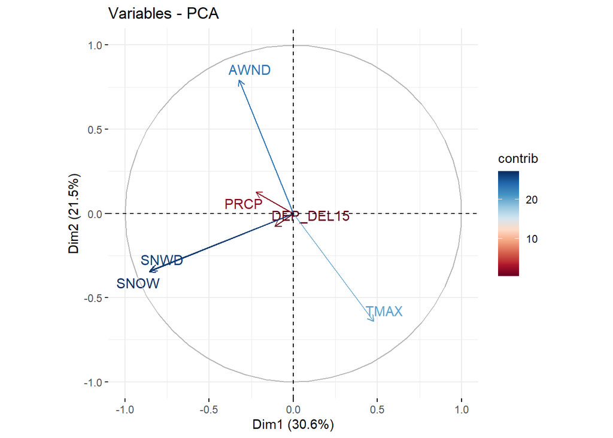

```r
p2 <- fviz_pca_var(outpca,
                   axes = c(1, 2),
                   col.var = "contrib",
                   gradient.cols = brewer.pal(n = 10, name = "RdBu"),
                   repel = TRUE
)
p2
```

Based on the correlation plot and the pca feature plot, we observe a positive correlation between “DEP_DEL15” and “PRCP” with which it has the highest correlation as well as with “SNOW” and “SWND”.

##### References

[1] - www.sthda.com. ggplot2 histogram plot : Quick start guide - R software and data visualization - Easy Guides - Wiki - STHDA. [online] Available at: http://www.sthda.com/english/wiki/ggplot2-histogram-plot-quick-start-guide-r-software-and-data-visualization.

[2] - www.sthda.com. Eigenvalues: Quick data visualization with factoextra - R software and data mining - Easy Guides - Wiki - STHDA. [online] Available at: http://www.sthda.com/english/wiki/eigenvalues-quick-data-visualization-with-factoextra-r-software-and-data-mining